# Meeting 10 - ANOVA

Matthew E. Aiello-Lammens

# Today’s Goals

- Understand when to apply ANOVA vs $t$ tests
- Identify correct $H_0$ for an ANOVA, and for an ANOVA with fixed vs. random effects
- Practice applying what we learned about the `t.test` function to a data set
- Learn how to apply the `lm`, `anova`, and `aov` functions to carry out an ANOVA
- Become familiar with multi-way ANOVA (bonus material!)

# Introduction to Analysis of Variance - ANOVA

In environmental science there are many times when we are working with **categorical** predictor variables and **continuous / numerical** response variables. For example, let’s consider a fertilizer addition experiment, where the growth of some plant species is measured under a fertilizer versus no-fertilizer treatment. Here, the predictor variable (fertilizer addition or not) is a categorical variable.

If our categorical predictor variable only has 2 levels (e.g., fertilizer vs. no fertilizer), then we may be able to examine differences between treatments using a $t$ test. However, if we are dealing with a categorical variable with 3 or more levels, then we need to move to ANOVA.

## Fixed versus Random Effects

Our categorical predictor variables can represent two different kinds of **factors** in our model, **fixed** vs **random** factors. In this course, we will only deal with **fixed** factors, but you should be aware of the differences between the two.

**Fixed factors** are ones we have manipulated, or that we expect *a priori* to have an effect on the response. From Logan, p 254 - “conclusions about the effects of a fixed factor are restricted to the specific treatment levels investigated …”

**Random factors** are, as per Logan, p. 254, “randomly chosen from all the possible levels of populations and are used as random representatives of the populations”. E.g., density of plants could be random. Or position of camera traps on a hillside.

## Null hypotheses

Our $H_0$s are different, depending on whether we are working with fixed versus random factors.

**Fixed effects model:**

$$H_0: \mu_1 = \mu_2 = ... = \mu_i = \mu$$

**Random effects model:**

$$H_0: \sigma^2_1 = \sigma^2_2 = ... = \sigma^2_i = \sigma^2$$

# One-way ANOVA

We will be using the a data set on **aldrin** concentration values at three different depths in the Wolf River. This case study is further described in the ANOVA lecture.

```r
aldrin <- read.csv("https://www.dropbox.com/s/sfstj4p8beajir5/aldrin.csv?dl=1")
summary(aldrin)
```

```
##      aldrin         depth
##  Min.   :3.100   Length:30
##  1st Qu.:4.300   Class :character
##  Median :4.900   Mode  :character
##  Mean   :5.097
##  3rd Qu.:5.625
##  Max.   :8.800
```

Let’s make a box plot of these data

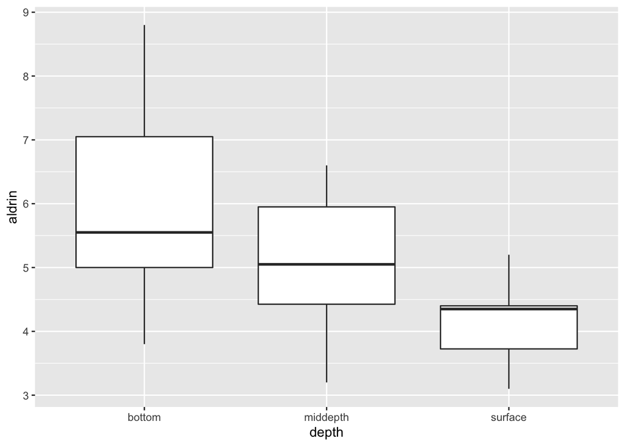

```r
library(ggplot2)

ggplot(data = aldrin, aes(x = depth, y = aldrin)) +
  geom_boxplot()
```

Just looking at the box plot, it does appear as though there are differences in the levels of aldrin at the different depths.

#### Challenge - Compare concentrations of aldrin at different depths with *t* test

There are three possible **pair-wise comparisons** we can do here:

- bottom - middle
- bottom - surface
- middle - surface

# Demonstration of ANOVA in R

## Carry out an ANOVA

ANOVA is a kind of linear model (we’ll talk more about this soon), so we use the `lm` function in R first.

```r
aldrin_lm <- lm(data = aldrin, aldrin~depth)
```

Next, we use a special summary command called `anova` to show the results of our linear model.

```r
anova(aldrin_lm)
```

```
## Analysis of Variance Table
##
## Response: aldrin
##           Df Sum Sq Mean Sq F value   Pr(>F)
## depth      2 16.961  8.4803  6.1338 0.006367 **
## Residuals 27 37.329  1.3826
## ---
## Signif. codes:  0 '***' 0.001 '**' 0.01 '*' 0.05 '.' 0.1 ' ' 1
```

You could do something similar with the `aov` function.

```r
aldrin_aov <- aov(data = aldrin, aldrin~depth)
summary(aldrin_aov)
```

```
##             Df Sum Sq Mean Sq F value  Pr(>F)
## depth        2  16.96   8.480   6.134 0.00637 **
## Residuals   27  37.33   1.383
## ---
## Signif. codes:  0 '***' 0.001 '**' 0.01 '*' 0.05 '.' 0.1 ' ' 1
```

## Testing model assumptions

We can use a set of data visualization tools to test for *some* of the assumptions of ANOVA (i.e., normality of residuals, independences of observations, equal variances).

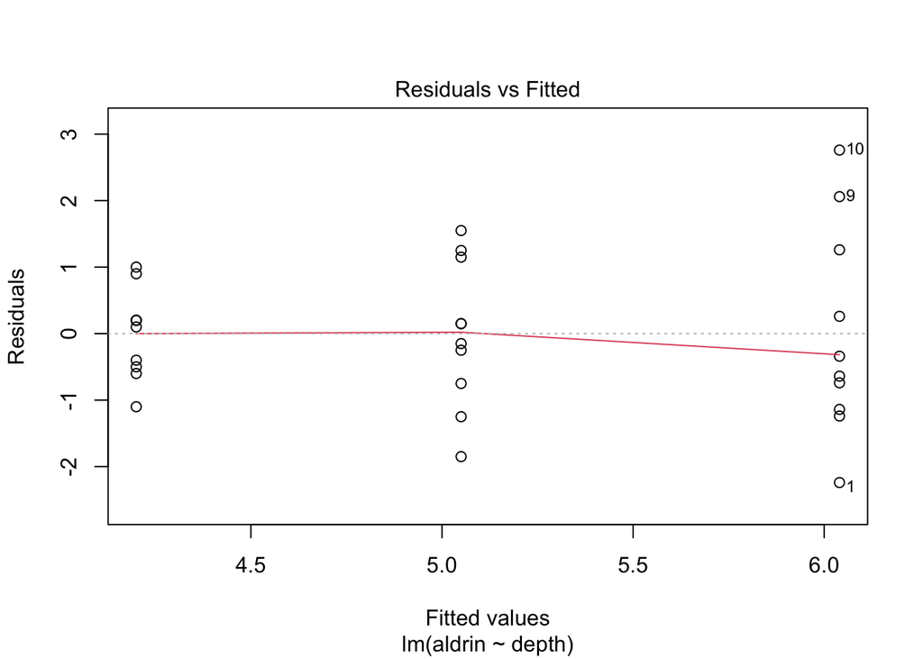

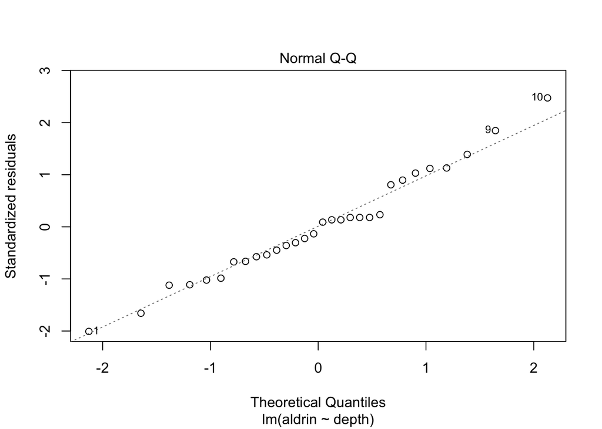

```
## hat values (leverages) are all = 0.1
##  and there are no factor predictors; no plot no. 5
```

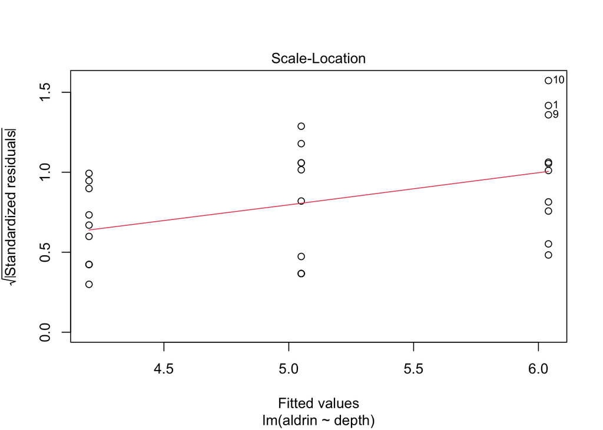

```r
plot(aldrin_lm)
```

In the lecture, I mention the possibility of doing multiple comparisons to test for which groups are different from each other. In practice, we would normally use a method like Tukey’s Honset Significant Differences test, which I implement below. Note that I use the `aov` command here, instead of the `anova(lm())` syntax.

```r
TukeyHSD(aov(data = aldrin, aldrin~depth))
```

```
##   Tukey multiple comparisons of means
##     95% family-wise confidence level
##
## Fit: aov(formula = aldrin ~ depth, data = aldrin)
##
## $depth
##                   diff       lwr       upr     p adj
## middepth-bottom  -0.99 -2.293785  0.313785 0.1630654
## surface-bottom   -1.84 -3.143785 -0.536215 0.0045163
## surface-middepth -0.85 -2.153785  0.453785 0.2561389
```

## Non-parametric ANOVA

As with many of the other methods we go over in this course, there are also non-parametric ANOVA approaches. The most common is the Kruskal-Wallace test, which uses **rank based** statistics. We wont be covering it here, but you can find information on this test by looking at the help file for the `kruskal.test` function or checking out these websites as a starting point - http://www.sthda.com/english/wiki/kruskal-wallis-test-in-r or https://rcompanion.org/rcompanion/d_06.html.

# Multi-way (Factorial) ANOVA

What if we want to look at two, or more, factors?

**See visuals as per Logan, Fig 12.1 and 12.2.**

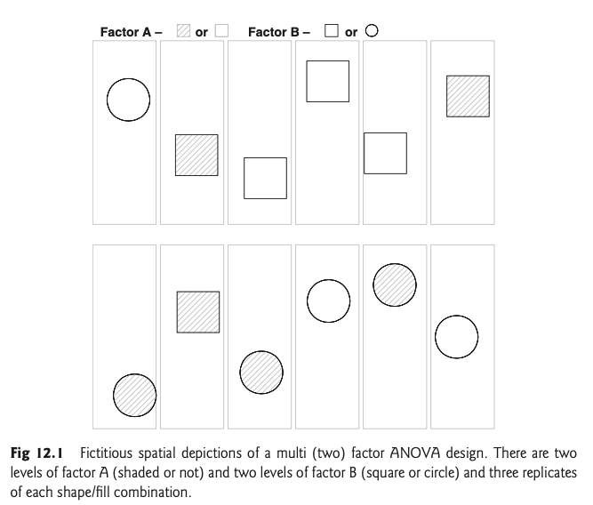

Logan - Figure 12.1

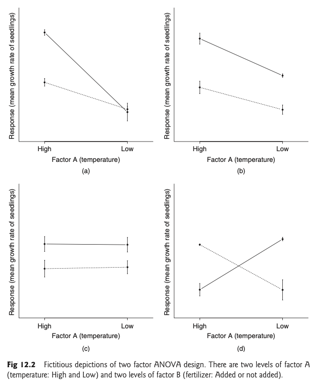

Logan - Figure 12.2

For formula, see Logan p. 314 and for calculation of F-ratios see Table 12.1.

### Two-way (two-factor) fixed effects model (Model I)

From Logan (Example 12A):

> Quinn (1988) manipulated the density of adults limpets within enclosures (8, 15, 30 and 45 individuals per enclosure) during two seasons (winter-spring and summer-autumn) so as to investigate the effects of adult density and season on egg mass production by intertidal limpets. Three replicate enclosures per density/season combination were used, and both density and season were considered fixed factors (from Box 9.4 of Quinn and Keough (2002)).

```r
limpets <- read.csv(file = "https://mlammens.github.io/ENS-623-Research-Stats/data/Logan_Examples/Chapter12/Data/quinn.csv")

head(limpets)
```

```
##   DENSITY SEASON  EGGS
## 1       8 spring 2.875
## 2       8 spring 2.625
## 3       8 spring 1.750
## 4       8 summer 2.125
## 5       8 summer 1.500
## 6       8 summer 1.875
```

```r
summary(limpets)
```

```
##     DENSITY         SEASON               EGGS
##  Min.   : 8.00   Length:24          Min.   :0.3560
##  1st Qu.:13.25   Class :character   1st Qu.:0.9165
##  Median :22.50   Mode  :character   Median :1.4330
##  Mean   :24.50                      Mean   :1.4717
##  3rd Qu.:33.75                      3rd Qu.:1.9227
##  Max.   :45.00                      Max.   :2.8750
```

```r
limpets$DENSITY <- factor(limpets$DENSITY)
```

Let’s get some visuals.

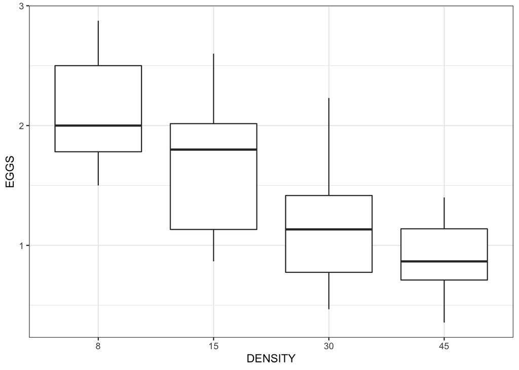

```r
ggplot(data = limpets) +
  geom_boxplot(aes(x = DENSITY, y = EGGS)) +
  theme_bw()
```

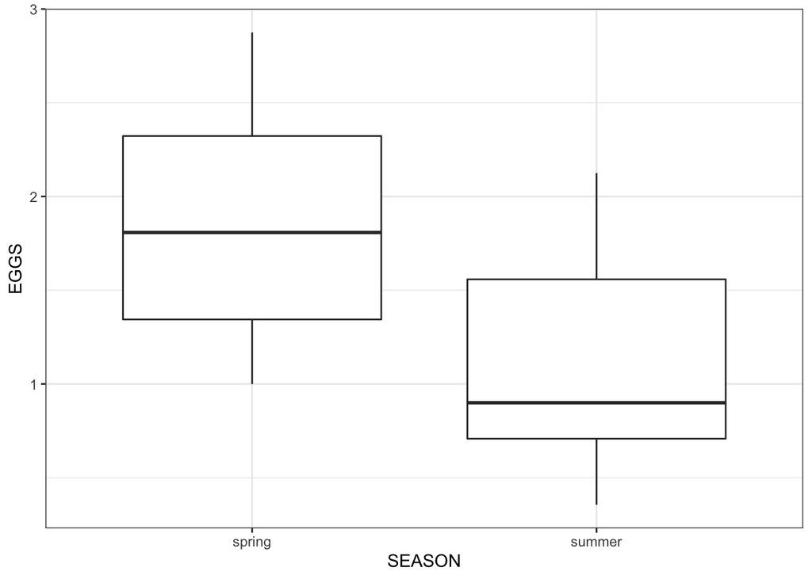

```r
ggplot(data = limpets) +
  geom_boxplot(aes(x = SEASON, y = EGGS)) +
  theme_bw()
```

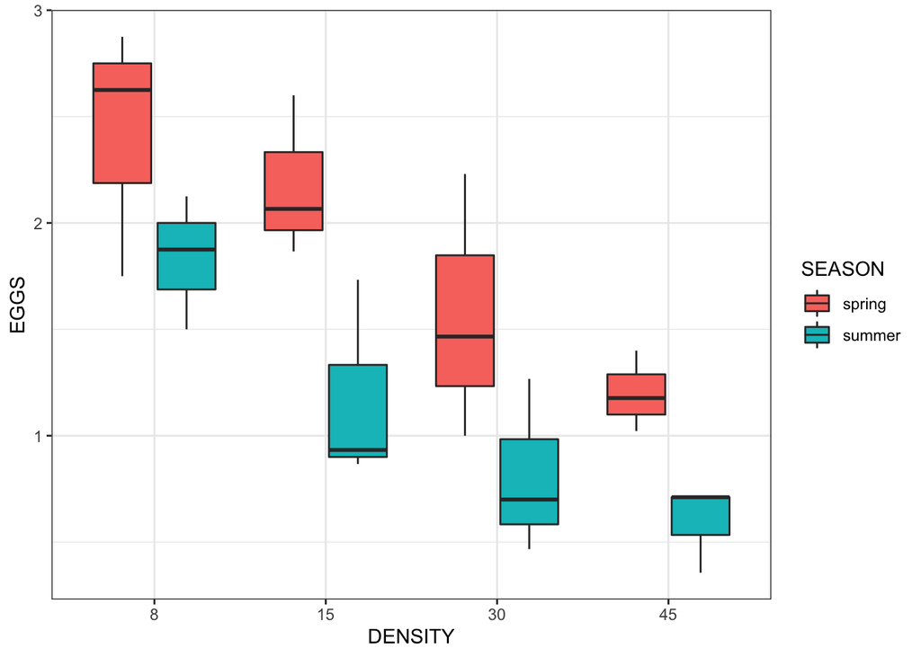

```r
ggplot(data = limpets) +
  geom_boxplot(aes(x = DENSITY, y = EGGS, fill = SEASON)) +
  theme_bw()
```

And let’s run the model.

```r
limpets_lm <- lm(data = limpets, formula = EGGS ~ SEASON * DENSITY)
summary(limpets_lm)
```

```
##
## Call:
## lm(formula = EGGS ~ SEASON * DENSITY, data = limpets)
##
## Residuals:
##     Min      1Q  Median      3Q     Max
## -0.6667 -0.2612 -0.0610  0.2292  0.6647
##
## Coefficients:
##                        Estimate Std. Error t value Pr(>|t|)
## (Intercept)             2.41667    0.24642   9.807  3.6e-08 ***
## SEASONsummer           -0.58333    0.34849  -1.674  0.11358
## DENSITY15              -0.23933    0.34849  -0.687  0.50206
## DENSITY30              -0.85133    0.34849  -2.443  0.02655 *
## DENSITY45              -1.21700    0.34849  -3.492  0.00301 **
## SEASONsummer:DENSITY15 -0.41633    0.49284  -0.845  0.41069
## SEASONsummer:DENSITY30 -0.17067    0.49284  -0.346  0.73363
## SEASONsummer:DENSITY45 -0.02367    0.49284  -0.048  0.96229
## ---
## Signif. codes:  0 '***' 0.001 '**' 0.01 '*' 0.05 '.' 0.1 ' ' 1
##
## Residual standard error: 0.4268 on 16 degrees of freedom
## Multiple R-squared:  0.749,  Adjusted R-squared:  0.6392
## F-statistic: 6.822 on 7 and 16 DF,  p-value: 0.000745
```

```r
anova(limpets_lm)
```

```
## Analysis of Variance Table
##
## Response: EGGS
##                Df Sum Sq Mean Sq F value    Pr(>F)
## SEASON          1 3.2502  3.2502 17.8419 0.0006453 ***
## DENSITY         3 5.2841  1.7614  9.6691 0.0007041 ***
## SEASON:DENSITY  3 0.1647  0.0549  0.3014 0.8239545
## Residuals      16 2.9146  0.1822
## ---
## Signif. codes:  0 '***' 0.001 '**' 0.01 '*' 0.05 '.' 0.1 ' ' 1
```

Plot the effects of Season and Density using the `allEffects` function in the `effects` package. You may need to use `install.packages` to install this package.

```r
library(effects)
```

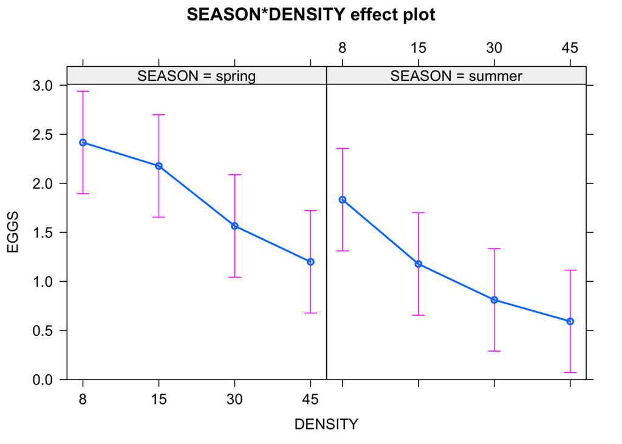

```r
plot(allEffects(limpets_lm))
```